# More on GGplot2 Customization

## Preamble

### Packages and Datasets

This lab will continue to use the `ggplot2` package:

```r
library(ggplot2)
```

We will also continue using data from The College Scorecard:

```r
colleges = read.csv("https://nfriedrichsen.github.io/data/Colleges2019.csv")
```

In the previous lab, we focused on the basic grammar used by `ggplot2`: aesthetics, geometric elements, layers, and facets. We also saw several ways to modify the appearance of a graphic.

This lab will focus on gaining more precise control over those graphics.

There are several related ideas that will appear throughout this lab:

| Component | What does it control? |
| --- | --- |
| **Mapping** | Which variables control visual properties such as position, color, fill, or shape |
| **Scale** | How the values of a mapped variable are represented visually |
| **Theme** | Non-data components of the graph, such as text, backgrounds, grid lines, and legend placement |
| **Guide** | How the reader interprets a scale, usually through a legend or color bar |

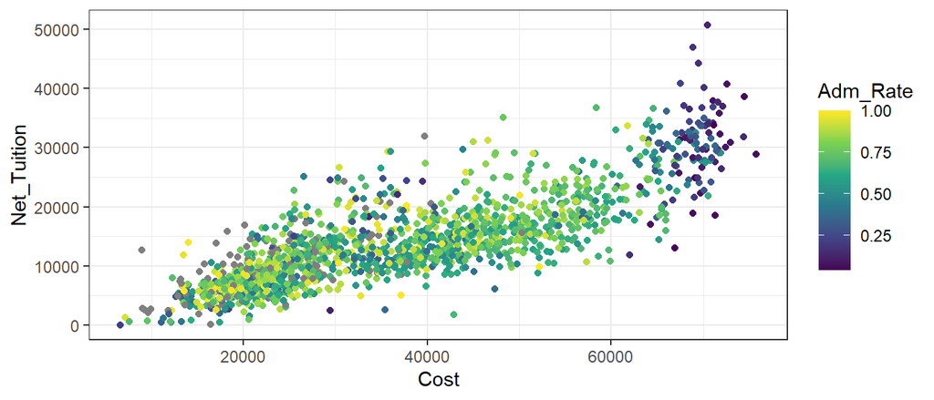

```r
ggplot(colleges, aes(x = Cost, y = Net_Tuition,
                     color = Adm_Rate)) +
  geom_point() +
  scale_color_viridis_c() +
  theme_bw()
```

For example, if we use `aes(color = Adm_Rate)`, we have **mapped** `Adm_Rate` to the color aesthetic. A function such as `scale_color_viridis_c()` controls the **scale** used to translate values of `Adm_Rate` into colors. The resulting color bar is a **guide** that allows the reader to interpret those colors. Changing the **theme** can modify the appearance of the graph without changing this mapping.

Another important distinction throughout this lab is between **discrete** and **continuous** variables. Different scales are appropriate for different types of variables, and recognizing this distinction will help you select appropriate scale functions and understand some common `ggplot2` error messages.

### What should I remember?

The goal of this lab is **not** to memorize every `ggplot2` option. In particular, you do not need to memorize theme component names, palette names, individual scale functions, hexadecimal color codes, or all of the arguments available within the `element_*()` functions. These are things you can look up when you need them.

Instead, you should understand:

- the difference between an aesthetic mapping and a scale
- how discrete and continuous variables require different types of scales
- the difference between the `color` and `fill` aesthetics
- what themes and guides control
- that individual layers can use their own data, mappings, and fixed appearance options.

In the next lab, we will focus more on answering this question: *which graphical choices are effective for displaying different kinds of data and relationships?* This lab will give us enough control over our graphics to make those choices.

$~$

# Customizing Themes

In the previous lab, we saw that `ggplot2` provides several pre-built themes. For example:

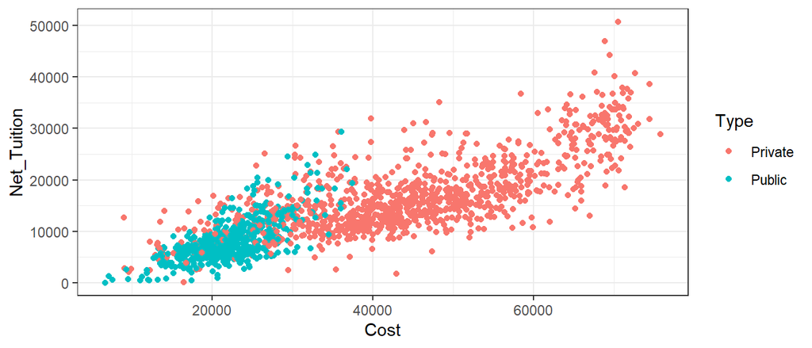

```r
ggplot(data = colleges,
       mapping = aes(x = Cost, y = Net_Tuition, color = Type)) +
  geom_point() +
  theme_bw()
```

Some commonly used themes include:

- `theme_bw()`
- `theme_linedraw()`
- `theme_light()`
- `theme_dark()`
- `theme_minimal()`
- `theme_classic()`
- `theme_void()`

These functions change the general appearance of a graphic. However, we can also modify individual components of a theme using the `theme()` function.

A useful distinction is that **themes control the non-data components of a graphic**. Changing a theme does not change which observations are displayed or how variables are mapped to aesthetics. Instead, themes control things such as text, backgrounds, grid lines, tick marks, and the placement of legends.

For example:

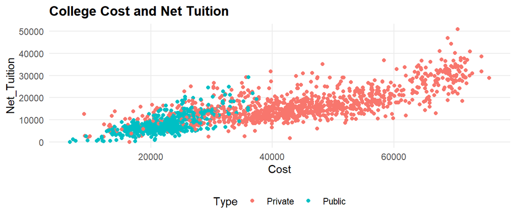

```r
ggplot(data = colleges,
       mapping = aes(x = Cost, y = Net_Tuition, color = Type)) +
  geom_point() +
  theme_minimal() +
  theme(
    legend.position = "bottom",
    plot.title = element_text(face = "bold"),
    panel.grid.minor = element_blank()
  ) +
  labs(title = "College Cost and Net Tuition")
```

The `theme()` function contains many possible arguments because there are many components of a graph that can be modified. Fortunately, most of these components are modified using only a few types of theme elements:

```r
element_text()
element_line()
element_rect()
element_blank()
```

The appropriate function depends upon the type of graphical element being modified.

## Text

Text components are modified using `element_text()`. This includes axis labels, axis tick labels, titles, and legend text.

For example:

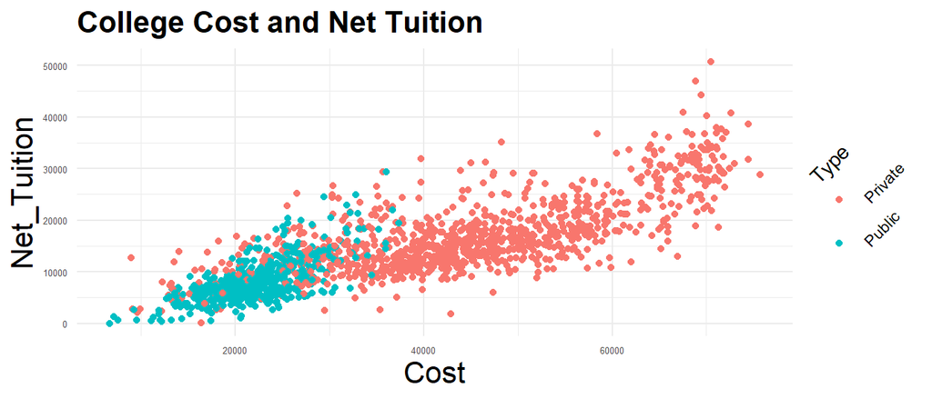

```r
ggplot(data = colleges,
       mapping = aes(x = Cost, y = Net_Tuition, color = Type)) +
  geom_point() +
  labs(title = "College Cost and Net Tuition") +
  theme_minimal() +
  theme(
    plot.title = element_text(size = 16, face = "bold"),
    axis.title = element_text(size = 16),
    axis.text = element_text(size = 5), #smol
    legend.text = element_text(angle = 45),
    legend.title = element_text(angle = 45, vjust=-.5)
  )
```

Some useful arguments within `element_text()` include:

```r
element_text(
  size = 12,
  face = "bold",
  color = "blue",
  angle = 45, #rotate
  hjust = 0.5, #horizontal adjustment (can be neg)
  vjust = 0.5 #vertical adjustment (can be neg)
)
```

You generally will not use all of these at once. They simply provide different ways to control how text is displayed.

Theme components can also be modified together or individually. For example,

```r
axis.text = element_text(size = 10)
```

modifies the text on both axes, while

```r
axis.text.x = element_text(angle = 45)
```

modifies only the x-axis tick labels.

## Lines

Line components are modified using `element_line()`. This includes grid lines, axes, and tick marks. Useful arguments include properties such as:

```r
element_line(
  color = "gray",
  linewidth = 0.5,
  linetype = "dashed"
)
```

For example:

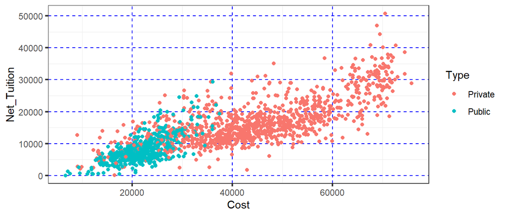

```r
ggplot(data = colleges,
       mapping = aes(x = Cost, y = Net_Tuition, color = Type)) +
  geom_point() +
  theme_bw() +
  theme(
    panel.grid.major = element_line(linewidth = 0.5, color="blue", linetype = "dashed"),
    panel.grid.minor = element_line(linewidth = 0.2),
    axis.ticks = element_line(linewidth = 0.8)
  )
```

You are most likely going to care about customizing colors, linewidths, and line types.

Here are options for line types. You can use either the integer value or the name like `"dashed"`.

| Integer | String | Appearance |
| --- | --- | --- |
| `0` | `"blank"` | No line is drawn |
| `1` | `"solid"` | Solid line (default) |
| `2` | `"dashed"` | Dashed line |
| `3` | `"dotted"` | Dotted line |
| `4` | `"dotdash"` | Alternating dots and dashes |
| `5` | `"longdash"` | Long dashed line |
| `6` | `"twodash"` | Alternating dash lengths |

## Rectangles and Backgrounds

Background regions and borders are generally modified using `element_rect()`.

For example:

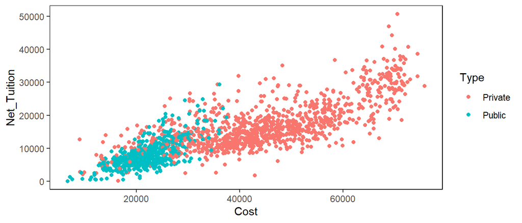

```r
ggplot(data = colleges,
       mapping = aes(x = Cost, y = Net_Tuition, color = Type)) +
  geom_point() +
  theme(
    panel.background = element_rect(fill = "white"),
    panel.border = element_rect(color = "black", fill = NA),
    legend.background = element_rect(fill = "white")
  )
```

For rectangular elements, `fill` controls the interior while `color` controls the border.

## Removing Elements

Sometimes the desired customization is simply to remove something. `element_blank()` removes a theme component entirely.

For example:

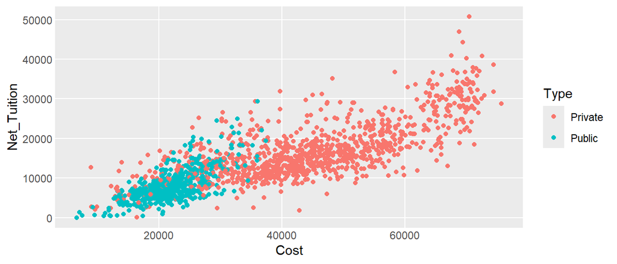

```r
ggplot(data = colleges,
       mapping = aes(x = Cost, y = Net_Tuition, color = Type)) +
  geom_point() +
  theme(
    panel.grid.minor = element_blank(),
    axis.ticks = element_blank()
  )
```

This is different from making an element white or transparent: the element is simply not drawn.

Many theme components follow a hierarchical naming structure. For example:

```r
plot.title         # Main plot title
plot.subtitle      # Plot subtitle

axis.text          # Axis tick labels on both axes
axis.text.x        # X-axis tick labels
axis.text.y        # Y-axis tick labels

axis.title         # Axis titles on both axes
axis.title.x       # X-axis title
axis.title.y       # Y-axis title

axis.ticks         # Tick marks on both axes

panel.grid         # All grid lines
panel.grid.major   # Major grid lines
panel.grid.minor   # Minor grid lines

panel.background   # Background of the plotting panel
panel.border       # Border surrounding the plotting panel

legend.text        # Labels for individual legend entries
legend.title       # Legend title
legend.background  # Background of the legend
```

The more general option changes all of the components beneath it, while a more specific option can be used when only one component should change.

You are **not expected to memorize all of the available theme components**. Instead, you should understand the general structure of `theme()` and recognize the four major element functions. When you want to modify a particular part of a graph, you can look up the appropriate theme component.

### Question 1

Begin with the following graph:

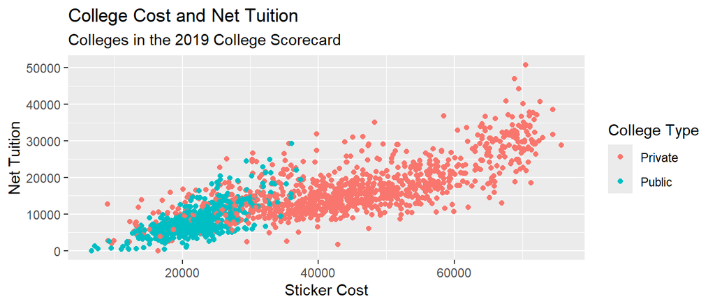

```r
ggplot(data = colleges,
       mapping = aes(x = Cost, y = Net_Tuition, color = Type)) +
  geom_point() +
  labs(
    title = "College Cost and Net Tuition",
    subtitle = "Colleges in the 2019 College Scorecard",
    x = "Sticker Cost",
    y = "Net Tuition",
    color = "College Type"
  )
```

Apply a non-default theme of your choice and then experiment with the following theme customizations. Your final graph does not need to represent choices you would make for a polished visualization (it can be ugly); the goal is to practice modifying different theme elements. Only one final graph needs to be shown for this lab submission.

**A.** Move the legend to the bottom of the graph.

**B.** Make the title larger and bold.

**C.** Remove the minor grid lines.

**D.** Modify one line element using `element_line()`.

**E.** Modify one rectangular element using `element_rect()`.

**F.** Make one additional theme modification of your choice that has not already been requested.

Briefly identify the theme component and `element_*()` function you used for Parts D, E, and F.

# Color Palettes

When a variable is mapped to the `color` or `fill` aesthetic, `ggplot2` automatically chooses a set of colors to represent its values. However, we are not restricted to these default colors.

A **color palette** is a collection or sequence of colors designed to be used together. `ggplot2` provides access to several families of pre-built palettes, and we can also construct our own.

For example, consider the default colors used to represent `Region`:

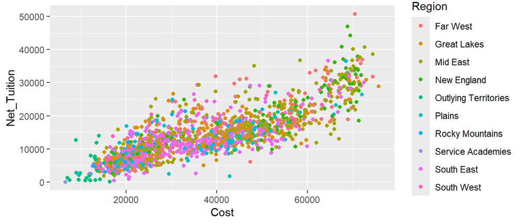

```r
ggplot(data = colleges,
       mapping = aes(x = Cost, y = Net_Tuition, color = Region)) +
  geom_point()
```

There are several ways that we can replace these default colors.

## ColorBrewer Palettes

One commonly used collection of palettes comes from **ColorBrewer**. These palettes can be accessed in `ggplot2` using functions such as `scale_color_brewer()`.

For example:

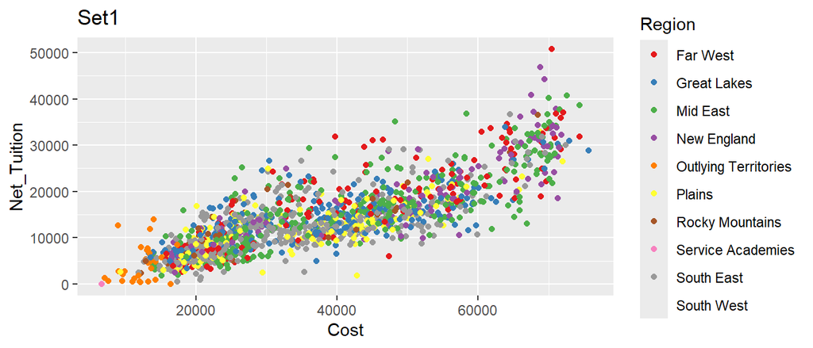

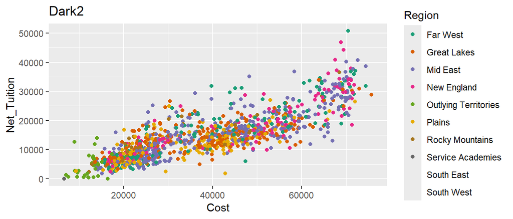

```r
ggplot(data = colleges,
       mapping = aes(x = Cost, y = Net_Tuition, color = Region)) +
  geom_point() +
  scale_color_brewer(palette = "Set1") +
  labs(title = "Set1")

ggplot(data = colleges,
       mapping = aes(x = Cost, y = Net_Tuition, color = Region)) +
  geom_point() +
  scale_color_brewer(palette = "Dark2") +
  labs(title = "Dark2")
```

The `palette` argument determines which collection of colors is used.

Some (but not all) available ColorBrewer palettes include: `"Set1"`, `"Set2"`, `"Set3"`, `"Dark2"`, `"Paired"`, `"Pastel1"`, `"Pastel2"`, `"Accent"`

These are examples of **qualitative palettes**. Qualitative palettes use different colors to distinguish categories without implying that one category is larger or smaller than another.

We can see the available “qualitative” (designed for categorical) ColorBrewer palettes using:

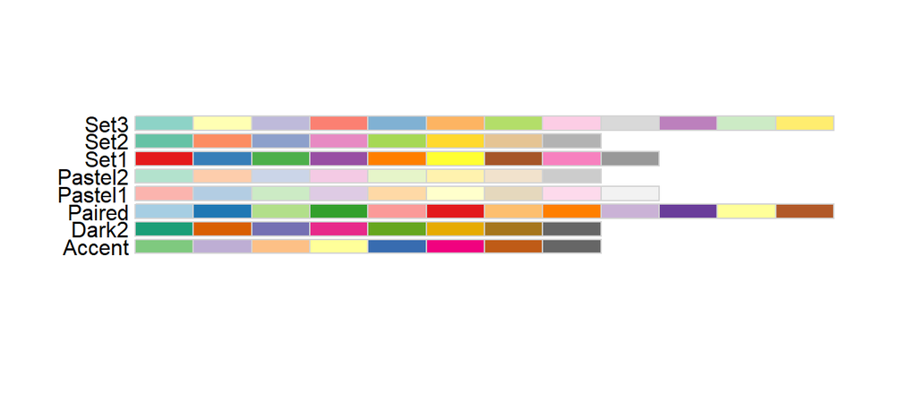

```r
RColorBrewer::display.brewer.all(type = "qual")
```

ColorBrewer also contains palettes designed for quantitative values. For example,

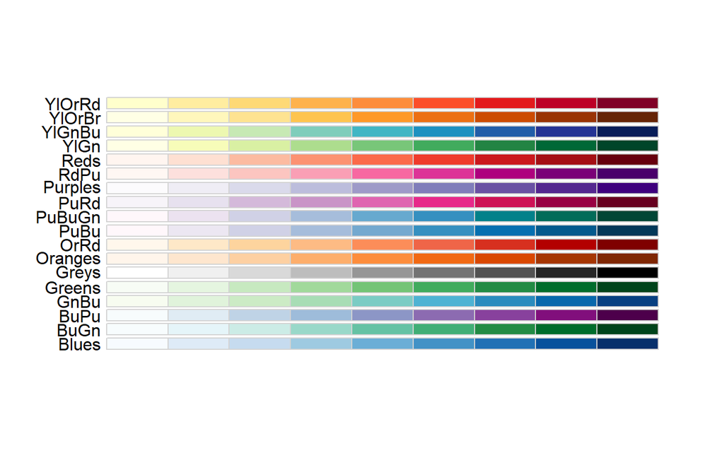

```r
RColorBrewer::display.brewer.all(type = "seq")
```

displays *sequential palettes*, while

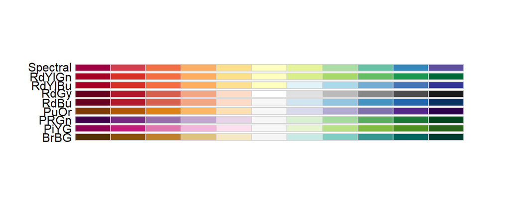

```r
RColorBrewer::display.brewer.all(type = "div")
```

displays *diverging* palettes.

**Sequential palettes** progress from one end of a color scale to another. **Diverging palettes** have two different ends with a contrasting color near the center.

For now, the important point is simply that different types of palettes exist. We will discuss more about choosing an effective palette for a particular purpose in the next lab.

### Question 2

Modify the graph we have been looking at and explore the different qualitative ColorBrewer palette options. Make a list of your favorite ones so far. Are there palettes that make the different regions easier or more difficult to distinguish?

```r
ggplot(data = colleges,
       mapping = aes(x = Cost, y = Net_Tuition, color = Region)) +
  geom_point()
```

$~$

## Viridis Palettes

Another commonly used family of color palettes that deserves special attention is **viridis**.

For example:

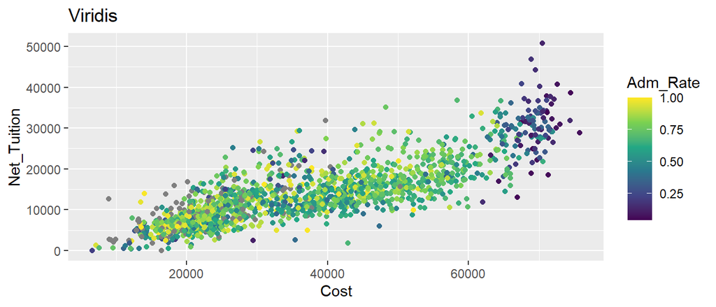

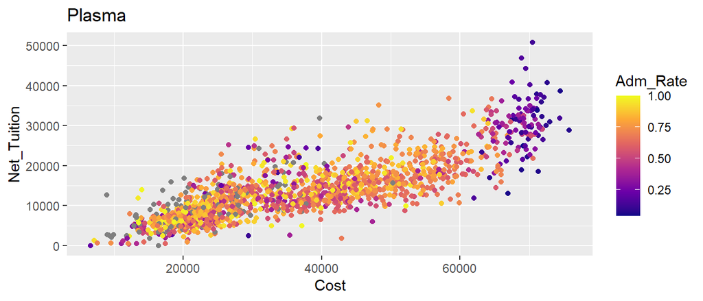

```r
ggplot(data = colleges,
       mapping = aes(x = Cost, y = Net_Tuition, color = Adm_Rate)) +
  geom_point() +
  scale_color_viridis_c(option = "viridis") +
  labs(title = "Viridis")

ggplot(data = colleges,
       mapping = aes(x = Cost, y = Net_Tuition, color = Adm_Rate)) +
  geom_point() +
  scale_color_viridis_c(option = "plasma") +
  labs(title = "Plasma")
```

Several palettes are available within this family:

`"viridis"`, `"magma"`, `"inferno"`, `"plasma"`, `"cividis"`, `"mako"`, `"rocket"`, `"turbo"`

The palette is selected using the `option` argument:

[figure not shown]

```r
scale_color_viridis_c(option = "magma")
```

The direction of the palette can also be reversed using `direction = -1`:

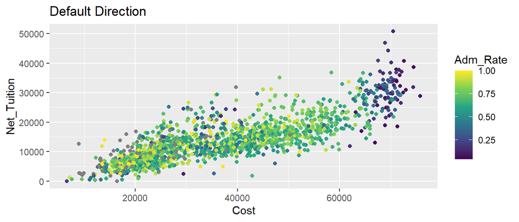

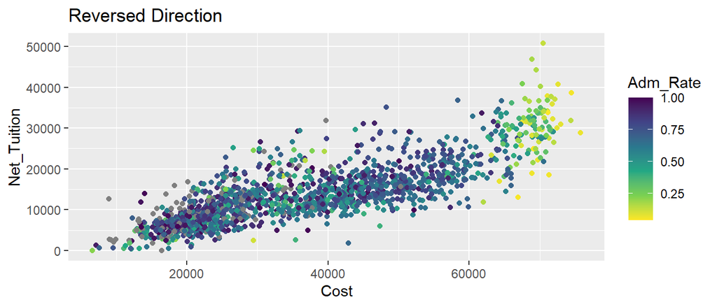

```r
ggplot(data = colleges,
       mapping = aes(x = Cost, y = Net_Tuition, color = Adm_Rate)) +
  geom_point() +
  scale_color_viridis_c() +
  labs(title = "Default Direction")

ggplot(data = colleges,
       mapping = aes(x = Cost, y = Net_Tuition, color = Adm_Rate)) +
  geom_point() +
  scale_color_viridis_c(direction = -1) +
  labs(title = "Reversed Direction")
```

### Question 3

For the plot below, experiment with the viridis color palettes and see which ones work best for this graph. Also try out if `direction=-1` gives you a better graph. `Salary10yr_median` is the median salary of graduates 10 years after graduating. What does this plot tell you about the relationship between these 3 variables?

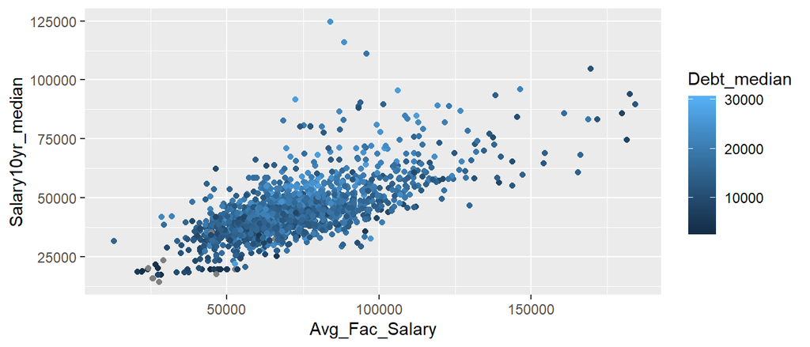

```r
ggplot(data = colleges, aes(x = Avg_Fac_Salary, color = Debt_median, y=Salary10yr_median)) + geom_point()
```

$~$

## Creating Color Gradients

We can also construct a continuous color palette directly.

The `scale_color_gradient()` function creates a gradient between two colors:

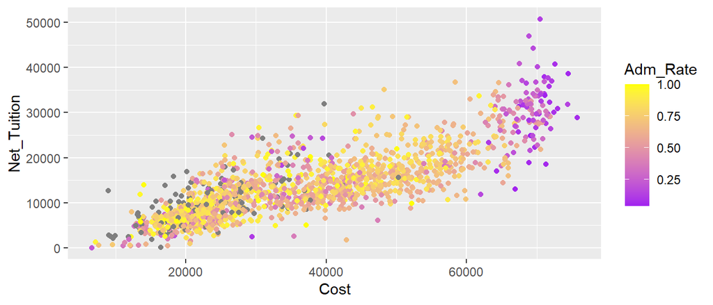

```r
ggplot(data = colleges,
       mapping = aes(x = Cost, y = Net_Tuition, color = Adm_Rate)) +
  geom_point() +
  scale_color_gradient(
    low = "purple",
    high = "yellow"
  )
```

Here, smaller values of `Adm_Rate` are represented closer to purple and larger values closer to yellow.

A gradient can also contain a specified middle color using `scale_color_gradient2`:

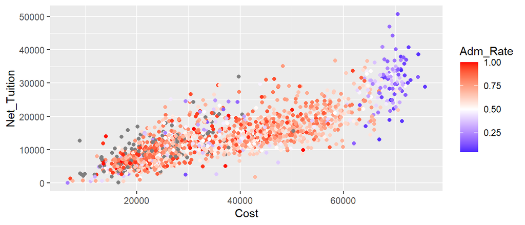

```r
ggplot(data = colleges,
       mapping = aes(x = Cost, y = Net_Tuition, color = Adm_Rate)) +
  geom_point() +
  scale_color_gradient2(
    low = "blue",
    mid = "white",
    high = "red",
    midpoint = 0.5
  )
```

The `midpoint` argument determines which numerical value receives the middle color. This creates a **diverging gradient** centered at the specified value.

$~$

## Choosing Colors Manually

For categorical variables, we can also specify the exact color assigned to each category.

For example:

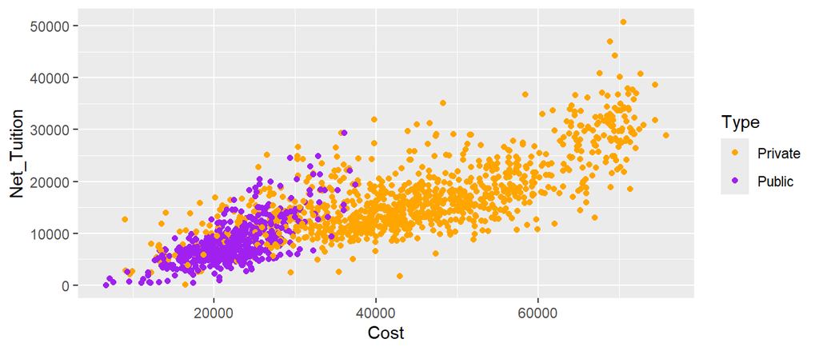

```r
ggplot(data = colleges,
       mapping = aes(x = Cost, y = Net_Tuition, color = Type)) +
  geom_point() +
  scale_color_manual(
    values = c(
      "Public" = "purple",
      "Private" = "orange"
    )
  )
```

Using a named vector makes the correspondence between categories and colors explicit:

```r
"Public" = "purple"
"Private" = "orange"
```

rather than relying upon the order in which the categories happen to appear.

Colors can be specified using many standard color names. You can see the named colors recognized by `R` using:

```r
# run this in your own console
colors()
```

`R` also understands hexadecimal color codes, which can be used when there is a particular color shade/hue/brightness combination you want.

```r
"#440154"
"#21918C"
"#FDE725"
```

$~$

# Scales

Throughout the previous section, we used several functions to change how colors were displayed:

```r
scale_color_brewer()
scale_color_viridis_c()
scale_color_gradient()
scale_color_gradient2()
scale_color_manual()
```

Although we introduced these functions as ways to choose color palettes, they are all examples of **scales**.

A scale controls how the values of a variable are translated into the visual properties of a graph. For example, suppose we map `Adm_Rate` to color:

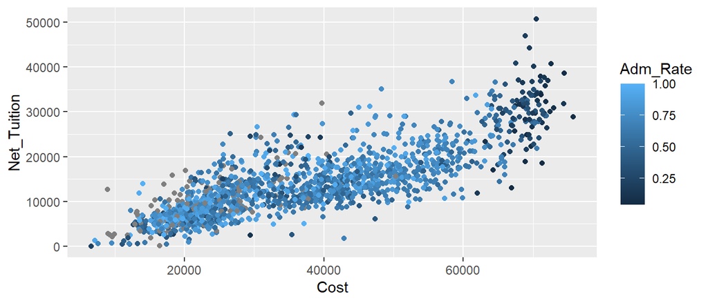

```r
ggplot(data = colleges,
       mapping = aes(x = Cost, y = Net_Tuition, color = Adm_Rate)) +
  geom_point()
```

The aesthetic mapping `color = Adm_Rate` tells `ggplot2` **which variable** should control color. The color scale determines **how the values of that variable are represented by colors**.

For example, both of the following graphs have exactly the same aesthetic mappings:

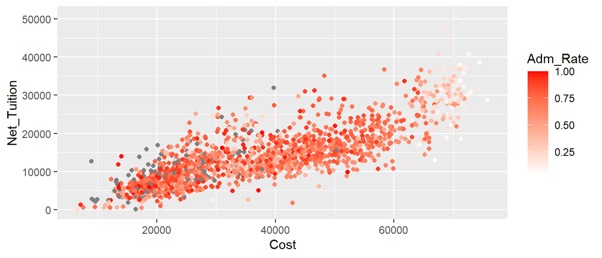

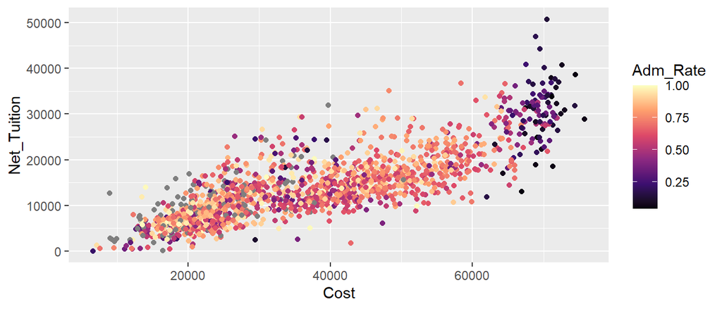

```r
ggplot(data = colleges,
       mapping = aes(x = Cost, y = Net_Tuition, color = Adm_Rate)) +
  geom_point() +
  scale_color_gradient(low = "white", high = "red")

ggplot(data = colleges,
       mapping = aes(x = Cost, y = Net_Tuition, color = Adm_Rate)) +
  geom_point() +
  scale_color_viridis_c(option = "magma")
```

The data and mappings have not changed. Only the **scale** used to display the `color` aesthetic has changed.

$~$

## Scale Functions

Scale functions generally follow a common naming structure:

```
scale_[aesthetic]_[type]()
```

The first part tells `ggplot2` which aesthetic is being controlled. For example:

```r
scale_color_...
scale_fill_...
scale_x_...
scale_y_...
```

The remainder of the function name describes the type of scale being used.

For example:

```r
scale_color_gradient()
scale_color_manual()

scale_fill_gradient()
scale_fill_manual()

scale_x_continuous()
scale_y_continuous()
```

This naming system means that once you understand how scales work, you do not need to memorize every possible scale function individually.

$~$

## Discrete and Continuous Scales

An important distinction is whether the variable mapped to an aesthetic is **discrete** or **continuous**.

A **discrete variable** consists of separate categories. For example, `Type` and `Region` are discrete variables.

A **continuous variable** is numerical and can take values along a numerical scale. For example, `Adm_Rate`, `Cost`, and `Net_Tuition` are continuous variables.

*For the math savvy: Please don’t yell at me about discrete also having different meaning for quantitative variables. I didn’t invent the system!*

Different scale functions are designed for these different types of variables.

For example, the following graph maps the categorical variable `Type` to color:

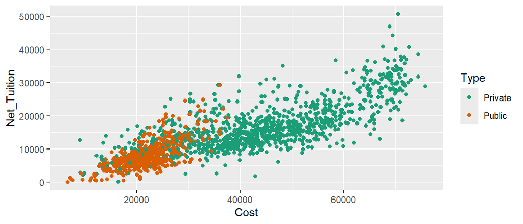

```r
ggplot(data = colleges,
       mapping = aes(x = Cost, y = Net_Tuition, color = Type)) +
  geom_point() +
  scale_color_brewer(palette = "Dark2")
```

In contrast, the following graph maps the quantitative variable `Adm_Rate` to color:

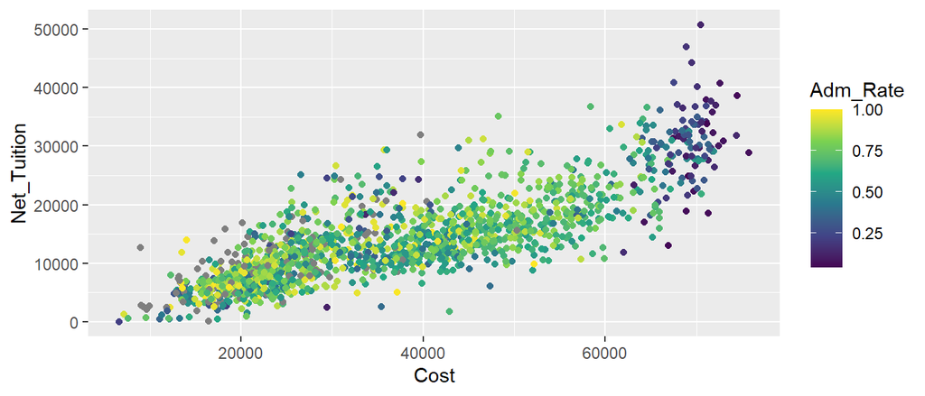

```r
ggplot(data = colleges,
       mapping = aes(x = Cost, y = Net_Tuition, color = Adm_Rate)) +
  geom_point() +
  scale_color_viridis_c()
```

Some scale functions make this distinction explicit in their names. In the viridis family, for example:

```r
scale_color_viridis_d()  # discrete
scale_color_viridis_c()  # continuous
```

The `_d` version is used when colors represent categories, while the `_c` version is used when colors represent values along a continuous numerical scale.

For example:

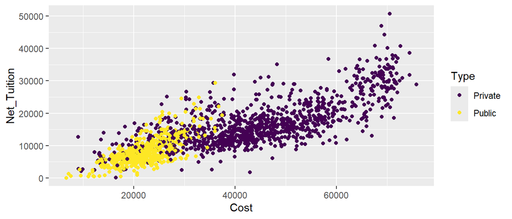

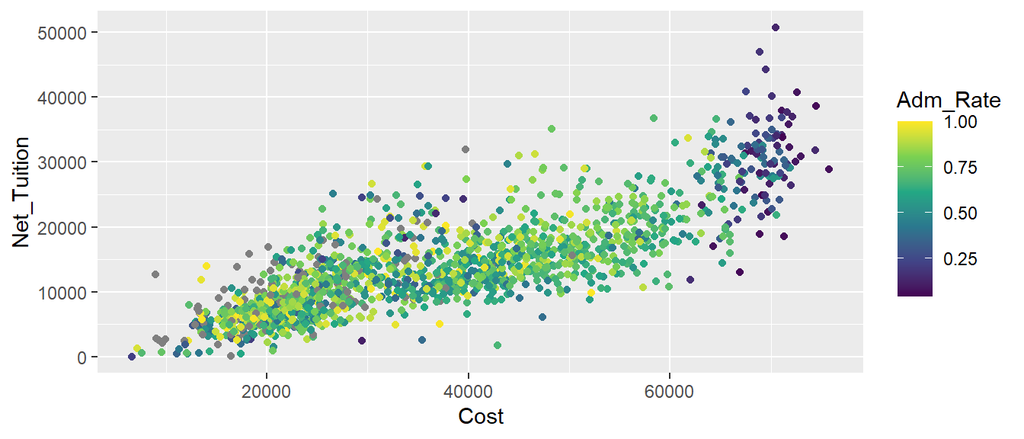

```r
ggplot(data = colleges,
       mapping = aes(x = Cost, y = Net_Tuition, color = Type)) +
  geom_point() +
  scale_color_viridis_d()

ggplot(data = colleges,
       mapping = aes(x = Cost, y = Net_Tuition, color = Adm_Rate)) +
  geom_point() +
  scale_color_viridis_c()
```

Other scale functions are designed specifically for one type of variable even if `_d` or `_c` does not appear in the function name. For example, `scale_color_gradient()` represents continuous values using a gradient, while `scale_color_manual()` allows us to assign values to individual categories.